# Lab #1 Basic R syntax/plots with data solutions

Xulin Ge

Jul 02 2023

We will be working with a data set that is comparing the transcript profiles from peripheral B lymphocytes between patients with systemic lupus erythematosus (SLE) and normal healthy controls

```r
# Set the directory
(WD <- getwd())
if (!is.null(WD)) setwd(WD)
```

# Read `sle_b_cell.txt` text file into R

```r
# using the read.table() function
txt_file <- "sle_b_cell.txt"
raw_table <- read.table(file=file.path("data", txt_file), header=T, row.names=1)
```

### Look at the dimensions of the data

There should be 26 samples.

```r
knitr::kable(head(raw_table), caption=" SLE B cell data set")
```

SLE B cell data set

|  | sle.1 | sle.2 | sle.3 | sle.4 | sle.5 | sle.6 | sle.7 | sle.8 | sle.9 | sle.10 | sle.11 | sle.12 | sle.13 | sle.14 | sle.15 | sle.16 | sle.17 | control.1 | control.2 | control.3 | control.4 | control.5 | control.6 | control.7 | control.8 | control.9 |
| --- | --- | --- | --- | --- | --- | --- | --- | --- | --- | --- | --- | --- | --- | --- | --- | --- | --- | --- | --- | --- | --- | --- | --- | --- | --- | --- |
| 1007_s_at | 7.201054 | 6.946045 | 6.722417 | 6.478136 | 7.657807 | 7.458431 | 7.128307 | 6.893233 | 7.417972 | 6.931443 | 7.043239 | 6.477673 | 7.257562 | 7.196866 | 7.215563 | 6.975056 | 6.946701 | 7.001722 | 7.674048 | 7.207480 | 7.237135 | 6.819833 | 7.261240 | 6.934885 | 7.003605 | 7.275157 |
| 1053_at | 6.329305 | 6.525640 | 6.323421 | 5.788303 | 7.064163 | 6.475585 | 6.394097 | 6.708787 | 6.457130 | 6.407173 | 6.124894 | 6.181405 | 6.471388 | 6.504524 | 6.638673 | 6.619250 | 6.427475 | 6.417270 | 6.583484 | 6.304779 | 6.631808 | 6.496153 | 6.584563 | 6.376337 | 6.355599 | 6.419475 |
| 117_at | 4.943542 | 4.075428 | 5.173628 | 5.161637 | 5.879714 | 5.207273 | 4.860286 | 4.589201 | 5.545966 | 5.397000 | 5.204737 | 5.510464 | 5.551032 | 4.594924 | 4.974176 | 4.452682 | 4.879310 | 6.204755 | 5.462083 | 5.162292 | 5.182004 | 5.214210 | 4.657415 | 5.199447 | 5.796467 | 4.687595 |
| 121_at | 5.964546 | 5.959280 | 5.956043 | 5.891120 | 6.207989 | 6.155414 | 5.936915 | 5.647587 | 6.175860 | 5.905099 | 5.619636 | 5.917675 | 6.130143 | 5.899389 | 6.665831 | 6.567843 | 5.931885 | 5.819153 | 5.634927 | 6.063086 | 5.618122 | 5.627996 | 6.050202 | 5.744575 | 6.366819 | 5.910187 |
| 1294_at | 8.798413 | 9.027502 | 9.478432 | 9.069233 | 9.210925 | 9.060505 | 8.605030 | 9.088855 | 9.002307 | 9.386652 | 9.434617 | 9.329697 | 8.469365 | 8.794065 | 9.255156 | 9.297987 | 8.527558 | 9.156431 | 9.028355 | 9.878348 | 8.880848 | 9.025513 | 8.503446 | 8.619609 | 9.285734 | 8.710406 |
| 1316_at | 4.272086 | 3.659428 | 3.673992 | 3.822420 | 3.735879 | 4.164235 | 3.724233 | 3.669170 | 4.107480 | 3.806881 | 3.715541 | 3.825745 | 3.875756 | 3.803949 | 3.870495 | 3.978532 | 4.068268 | 3.889457 | 3.725608 | 4.024489 | 3.778687 | 3.826248 | 3.826856 | 3.811117 | 3.990947 | 3.830298 |

### Print the sample names to screen

```r
colnames(raw_table)
```

```
##  [1] "sle.1"     "sle.2"     "sle.3"     "sle.4"     "sle.5"     "sle.6"
##  [7] "sle.7"     "sle.8"     "sle.9"     "sle.10"    "sle.11"    "sle.12"
## [13] "sle.13"    "sle.14"    "sle.15"    "sle.16"    "sle.17"    "control.1"
## [19] "control.2" "control.3" "control.4" "control.5" "control.6" "control.7"
## [25] "control.8" "control.9"
```

# Plot the second SLE patient sample versus the first normal control samples

Select the sample

```r
x1 <- raw_table["control.1"][ , 1]
y1 <- raw_table["sle.2"][ , 1]
```

### Plot in an xy scatter plot

Label the x and y-axes as ‘Normal’ and ‘SLE’, respectively. Title the plot Add grey grid lines with the function `grid()`

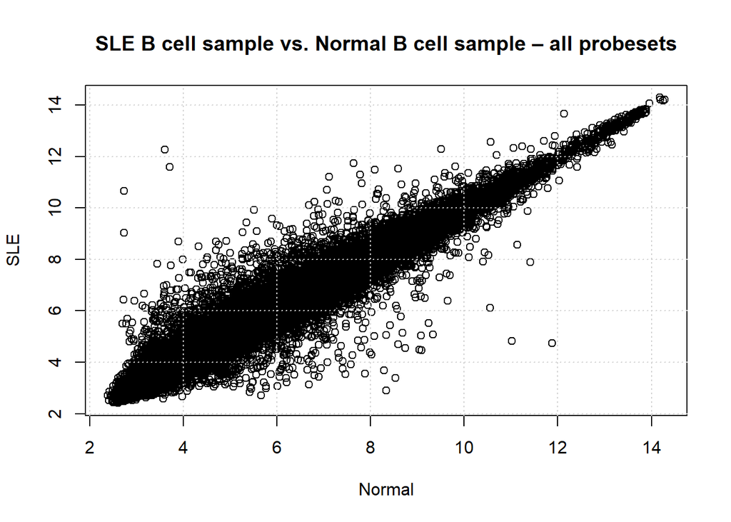

```r
plot1 <- plot(x1, y1, xlab="Normal", ylab="SLE",
    main="SLE B cell sample vs. Normal B cell sample – all probesets")
grid()
```

# Do the same plot but pick only the first 20 probesets

Pick only the first 20 probesets

```r
x2 <- x1[1:20]
y2 <- y1[1:20]
```

Use the `pch=15` argument to change the shape and color the points blue with the `col` argument

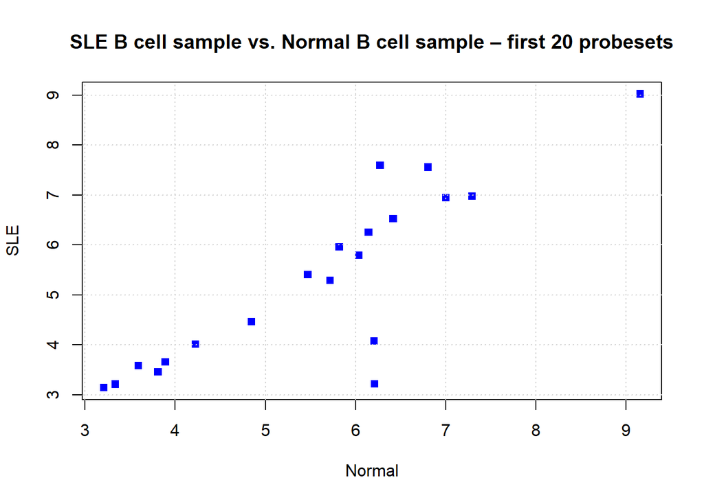

```r
plot2 <- plot(x2, y2, xlab="Normal", ylab="SLE",
    main="SLE B cell sample vs. Normal B cell sample – first 20 probesets",
    pch=15, col="blue") + grid()
```

# Plot the following gene in a gene profile plot

### IGLJ3 (immunoglobulin lambda joining 3), which is probeset ID `211881_x_at`.

This type of plot has the sample indices across the x-axis and the intensities on the y-axis

```r
# sample indices across the x-axis
x3 <- 1:26
# intensities on the y-axis cast to numeric
y3 <- as.numeric(raw_table["211881_x_at", ])
```

### First plot the ranges using the `type="n"` argument

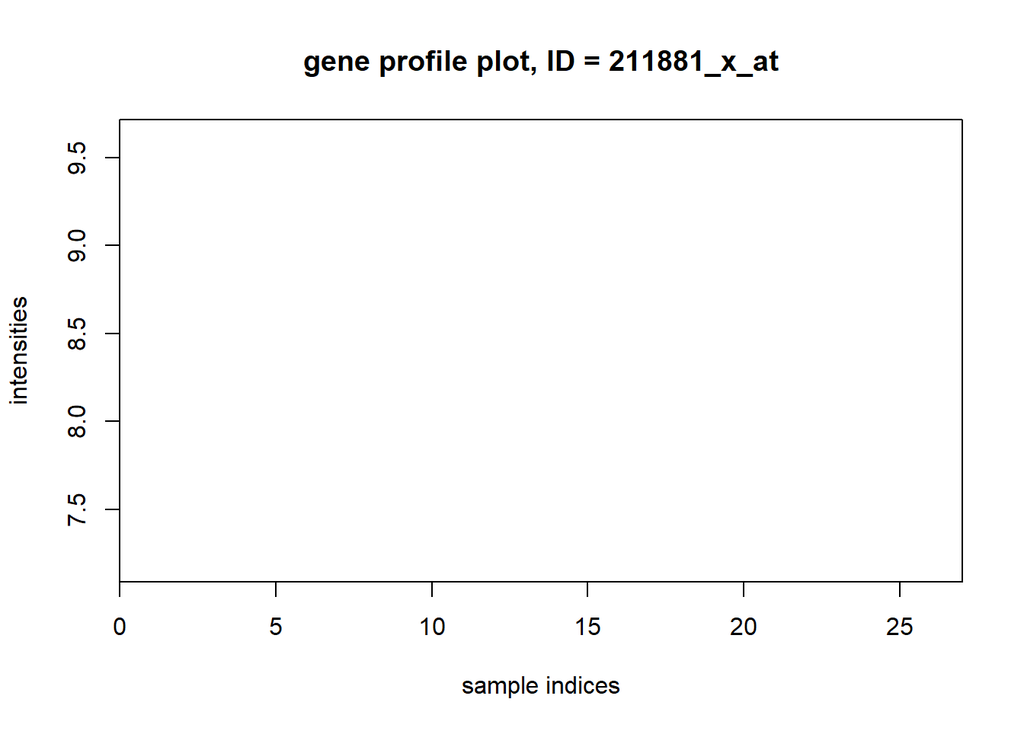

```r
plot(range(x3), range(y3), type="n",
    xlab="sample indices", ylab="intensities",
    main="gene profile plot, ID = 211881_x_at")
```

### Then add the genes with the `lines()` function call. Add grid lines

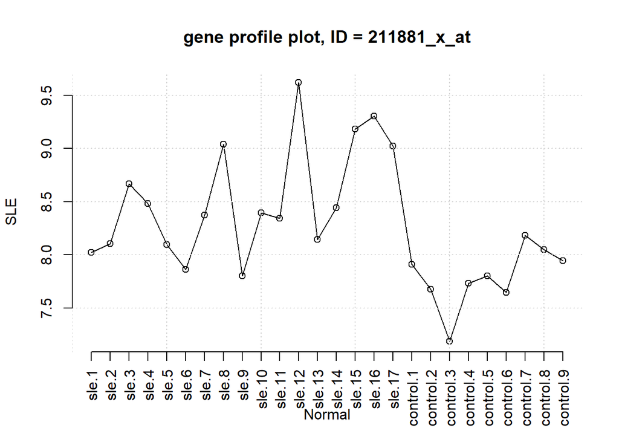

```r
plot(x3, y3,
    xlab="Normal", ylab="SLE",
    main="gene profile plot, ID = 211881_x_at",axes=F)
lines(x3, y3)
grid()
# las=2: labels are perpendicular(=2) to axis
axis(1, at=x3, colnames(raw_table), las=2, cex.lab=0.8)
axis(2)
```

# Boxplot

Another way to visualize a gene profile across conditions is to graph a boxplot with a single distribution box per condition.

To do this, we need to create a factor vector that indicates the disease or normal condition like so: `f <- c(rep("SLE",17),rep("Control",9))`

Then use this vector with the expression vector for IGLJ3 in the boxplot function to create the graph

Add points with `stripchart()` function

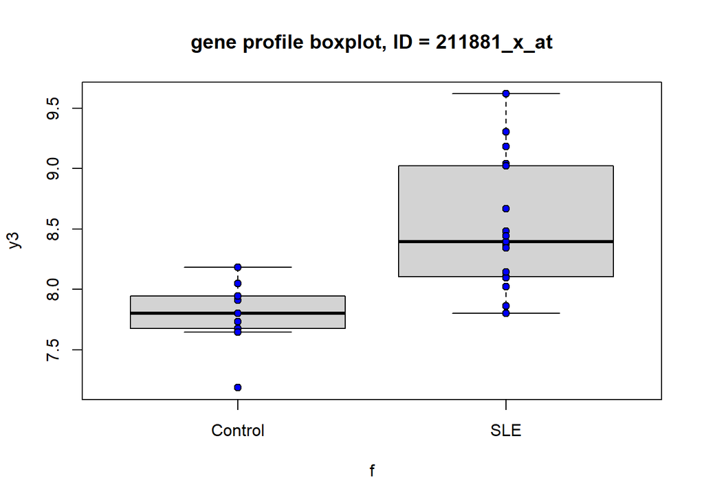

```r
f <- c( rep("SLE",17), rep("Control",9) )
boxplot(y3~f, main="gene profile boxplot, ID = 211881_x_at")
stripchart(y3~f, add=TRUE, vertical=TRUE, pch=21, bg="blue")
```